# STAT 605 Final Project Report

Samach Sathitvudh, Sheng Huang, Kyungjin Cho, Shravan Kaul, Midhun Satheesh

## Introduction

Global warming issue starts our motivation since it has been a long-term crucial topic throughout many decades. Even though global warming depends on the change of several factors, changes in temperature appear to be the primary indicator of global warming. Hence, as a data scientist, we took up this as a challenge motivates us to study the effect of climate factors to the change in temperature, leading to global warming sign by using cutting edge data analysis and alternative Machine Learning and Statistical Modeling approach, which eventually allows us to propose the question for the analysis which is: **“Do climate factors significantly affect the probability of global warming?”**

We utilized the potential of CHTC to preprocess 70 years of data files in parallel by choosing necessary columns as well as calculating average temperature in each year which will be used for identifying overheat sign, the response variable, while the independent variables are climate factors such as temperature, rain, snow precipitation and snow depth. Running jobs on CHTC takes about 20 minutes to complete with the request for disk and memory of 20 gigabytes.

We perform data visualization to discover ambiguous yet impressive insights and build a binary logistic regression model in R to evaluate the probability of overheating.Our findings reveal that minimum temperature in the U.S. is rising and there are significant relationships between most of climate factors and overheat sign. Besides, the model’s 89 percent accuracy confirmed that the relationships exist.

## Analysis report

### Dataset ([Click](https://www.kaggle.com/noaa/noaa-global-historical-climatology-network-daily))

The original data set (15 GB) consists of daily climate records measured at different stations around the world. We focused on studying the effect of the climate factors on the overheating sign in the US. The following features were used in our analysis.

- TOBS = Temperature at a time of observation (tenth of degree C) [later converted to degree C]
- TMAX = Maximum temperature (tenth of degree C) [later converted to degree C]
- TMIN = Minimum temperature (tenth of degree C) [later converted to degree C]
- PRCP = Rain precipitation (tenth of mm) [later converted to mm]
- SNOW = Snow precipitation (mm)
- SNWD = Snow depth (mm)

We began transforming each raw data by pivoting, selecting measures, removing some empty observations and calculating average temperature in each year. After we get “totalMean” column (the average temperature), we merged 70 processed files together into one cleaned data set. The sample data set after processing is shown below:

```
##            V1       V2 TOBS TMAX TMIN PRCP SNOW SNWD totalMean
## 1 USC00131731 19990101 -106 -106 -167   25   51  152  41.06476
## 2 USC00488852 19990101  -39    6  -39    0    0   25  41.06476
## 3 USC00212842 19990101 -339 -183 -356    0    0  152  41.06476
## 4 USC00407359 19990101  -89   17  -94    0    0    0  41.06476
```

where V1 is station_id, V2 is date_id

We decided to run 70 jobs in parallel on CHTC with a disk and memory request of 20GB. The job time was approximately 20 to 30 minutes to complete so as to obtain the processed data set.

### Statistical computation and results

According to the statistical question, we performed **“Binary logistic regression”** to evaluate the probability of overheating. Firstly, We must create the response variable, “TOBS_is_overheated”, regardless of station_id and date_id (figure 0). The conditions of labeling this variable are:

- TOBS_is_overheated = 1 : if the TOBS is larger than previous year average temperature
- TOBS_is_overheated = 0 : otherwise

#### Data summary (Figure 1.1)

It is shown that there might be some extreme value for some variables such as PRCP, SNOW, SNWD due to a very small value of average and 3rd quantile. This does not occur clearly for temperature variables.

#### Temperature plots (Figure 1.2)

In this plot, we can see that minimum temperature in the U.S. has been increasing overtime while maximum and observed temperature have been slightly decreasing. This might be a sign that the colder areas have been getting hotter these days.

#### Snow plots (Figure 1.3)

This plot demonstrates the snow precipitation and snow depth. We notice that snow depth has been always fluctuating and increased to a peak around 1990, but after 2010, the amount was dramatically dropped to the lowest which also corresponds to the increased minimum temperature. This confirms the world is getting warmer.

#### Binary logistic regression model

In this case, we build the binary logistic model which can be used to interpret the probability of the overheating which refers a sign of global warming. Likewise, based on the data count (figure 1.1), it shows that the response variable which is binary is relatively balanced and appropriate for fitting the logistic regression model.

The model reveals that the binary logistic model is:
$$P(Overheat) =\frac{1}{1+exp(0.038-3.283T_{max}-1.305T_{min}+0.09PRCP-0.075SNOW+0.004SNWD)}$$
According to the model summary (figure 2.1), if the maximum temperature increases for one unit, the odds of overheating increases the most by the factor of $exp(3.283) = 26.66$.

The model provides us that each variable except snow depth (SNWD) has a significant relationship to the response variable with 89 % accuracy obtained from the confusion matrix.

We also tried to build another model without including snow depth (SNWD). The result shows no difference in both estimated coefficients and accuracy.

### Weaknesses and limitations

- The data is not perfectly well-structured since it contains a lot of empty and unreasonable value.
- The number of measured climate factors are limited, so that few variables are included in the model.
- The data measured in different station is not consistent in each year. This only allows us to calculate the average temperature the whole year which leads to some bias.

## Conclusion

According to the results we obtained, there are significant signals telling us that global warming still exists and is getting worse due to the increase in minimum temperature and decrease in snow amount. Additionally, there is enough evidence to conclude that climate factors significantly relate to the probability of the overheating sign with very high accuracy. The capabilities of CHTC also helped us process a large data set and played a major role in decreasing delay of processing. However, there are some difficulties regarding the disk and memory request.

We could suggest the improvements for the future work as follows:

- More climate factors, such as atmospheric pressure, humidity and fog density, could be included.
- Alternatively, more aspect of data should be included such as an effect of using plastic bags or an emission of some gases such as carbon dioxide.
- We could find another approach to calculate overheating or global warming sign. One suggestion is calculating average temperature based on each station or using moving average in time series analysis.
- Incorporating more sophisticated models such as Random Forest Classification.
- The more data obtain, the more reliable model will be, so that we might consider adding more observations to improve the efficiency of the model.

### Appendix

**Figure 0: Final data used in the analysis**

```
##    TOBS TMAX  TMIN PRCP SNOW SNWD TOBS_is_overheated
## 1   6.1  6.7  -0.6  0.0    0    0                  0
## 2 -14.4 -7.8 -21.1  0.0    0  102                  0
## 3  10.0 15.0   8.9  0.0    0    0                  0
## 4   7.2 12.2   6.7  0.5    0    0                  0
```

**Figure 1.1: Data summary**

```
##       TOBS             TMAX             TMIN              PRCP
##  Min.   :-55.60   Min.   :-53.90   Min.   :-56.700   Min.   :  0.000
##  1st Qu.:  5.60   1st Qu.: 12.20   1st Qu.: -1.100   1st Qu.:  0.000
##  Median : 15.00   Median : 21.10   Median :  6.700   Median :  0.000
##  Mean   : 13.65   Mean   : 19.62   Mean   :  5.899   Mean   :  2.489
##  3rd Qu.: 22.20   3rd Qu.: 28.30   3rd Qu.: 13.900   3rd Qu.:  0.500
##  Max.   : 51.70   Max.   : 52.20   Max.   : 38.900   Max.   :457.200
##       SNOW               SNWD         TOBS_is_overheated
##  Min.   :   0.000   Min.   :   0.00   Min.   :0.0000
##  1st Qu.:   0.000   1st Qu.:   0.00   1st Qu.:0.0000
##  Median :   0.000   Median :   0.00   Median :1.0000
##  Mean   :   2.422   Mean   :  29.62   Mean   :0.5351
##  3rd Qu.:   0.000   3rd Qu.:   0.00   3rd Qu.:1.0000
##  Max.   :1372.000   Max.   :7010.00   Max.   :1.0000
```

```
##   dataset$TOBS_is_overheated       n
## 1                          0 2548443
## 2                          1 2933450
```

**Figure 1.2: Temperature plots**

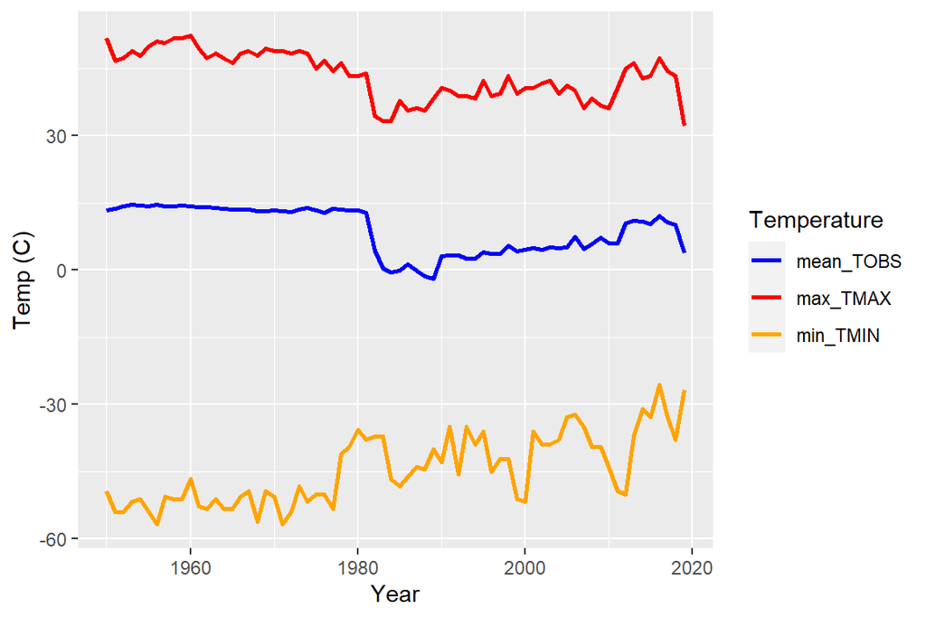

**Figure 1.3: Snow plots**

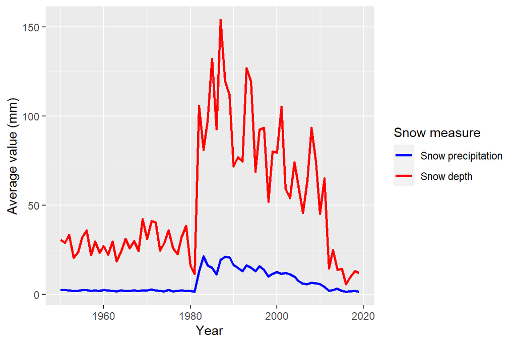

**Figure 1.4: Other plots**

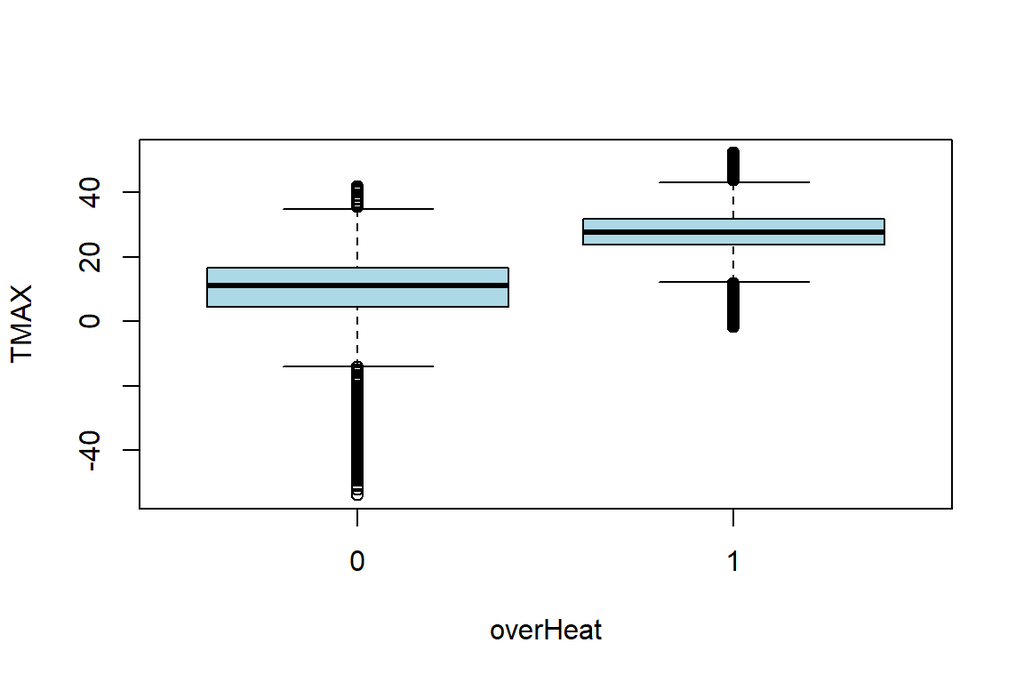

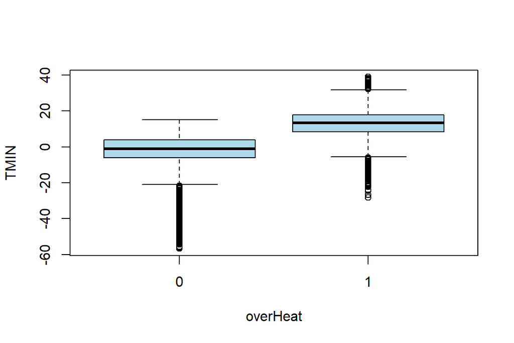

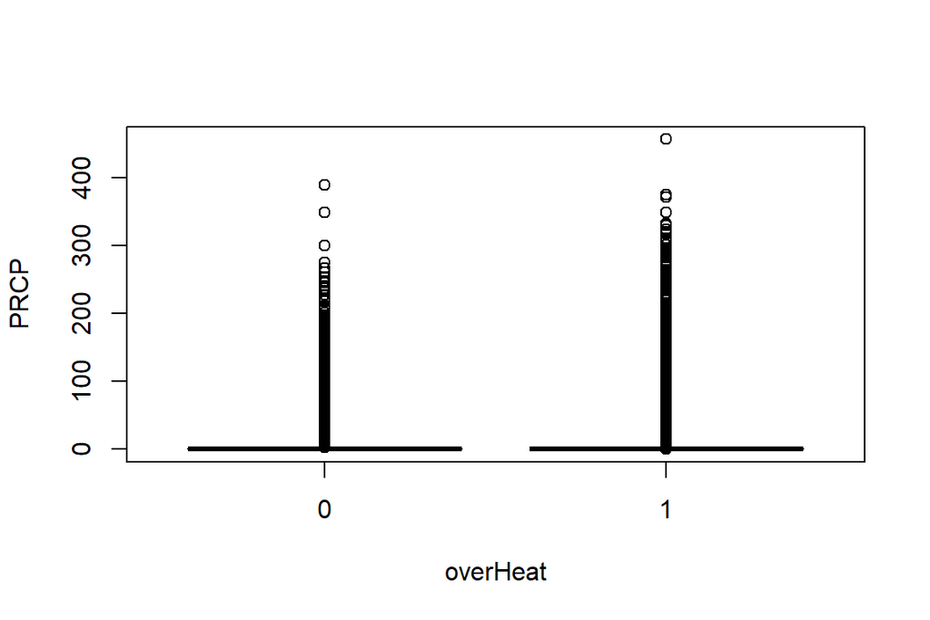

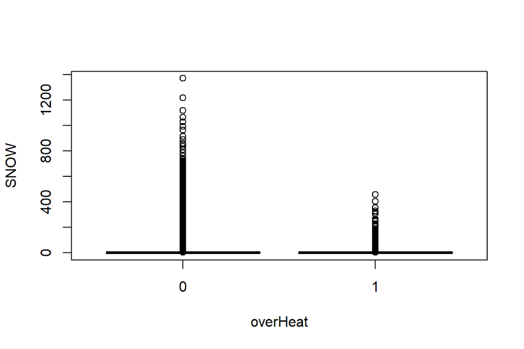

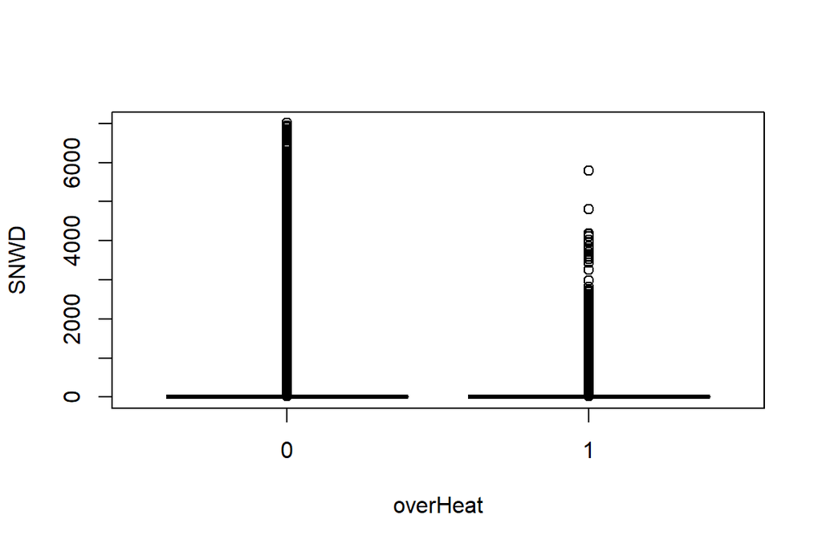

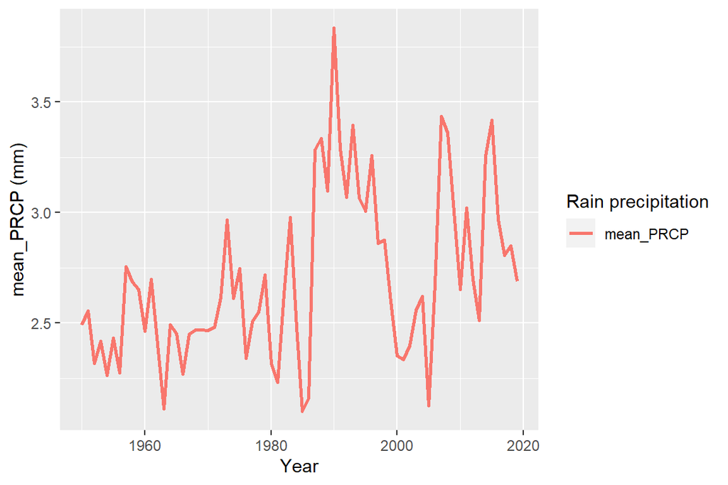

**Figure 2.1: Model summary**

```
##
## Call:
## glm(formula = TOBS_is_overheated ~ TMAX + TMIN + PRCP + SNOW +
##     SNWD, family = binomial, data = training_set_obs)
##
## Deviance Residuals:
##     Min       1Q   Median       3Q      Max
## -3.7359  -0.2383   0.0584   0.3091   4.2887
##
## Coefficients:
##              Estimate Std. Error z value Pr(>|z|)
## (Intercept) -0.037504   0.002160 -17.360   <2e-16 ***
## TMAX         3.283046   0.004855 676.277   <2e-16 ***
## TMIN         1.305436   0.004005 325.962   <2e-16 ***
## PRCP        -0.090166   0.001711 -52.713   <2e-16 ***
## SNOW         0.074580   0.007244  10.295   <2e-16 ***
## SNWD        -0.004087   0.005301  -0.771    0.441
## ---
## Signif. codes:  0 '***' 0.001 '**' 0.01 '*' 0.05 '.' 0.1 ' ' 1
##
## (Dispersion parameter for binomial family taken to be 1)
##
##     Null deviance: 5679342  on 4111419  degrees of freedom
## Residual deviance: 2040860  on 4111414  degrees of freedom
## AIC: 2040872
##
## Number of Fisher Scoring iterations: 8
```

```
## [1] "Confusion Matrix"
```

```
##
##      FALSE   TRUE
##   0 557183  79928
##   1  70782 662580
```